# NAB spore analyses

Yiluan Song

11/18/2021

# **Explore data**

## Read and clean NAB data

The complete dataset has both pollen and spore count. In this analysis we focus on spores.

```
## # A tibble: 3,900,672 x 9
##    Date                taxa     group count station   location   lat   lon    id
##    <dttm>              <chr>    <chr> <dbl> <chr>     <chr>    <dbl> <dbl> <int>
##  1 2009-03-17 00:00:00 Acer     poll…    12 Certifie… Albany,…  42.7 -73.8    15
##  2 2009-03-17 00:00:00 Alnus    poll…     0 Certifie… Albany,…  42.7 -73.8    15
##  3 2009-03-17 00:00:00 Ambrosia poll…     0 Certifie… Albany,…  42.7 -73.8    15
##  4 2009-03-17 00:00:00 Artemis… poll…     0 Certifie… Albany,…  42.7 -73.8    15
##  5 2009-03-17 00:00:00 Betula   poll…     0 Certifie… Albany,…  42.7 -73.8    15
##  6 2009-03-17 00:00:00 Carya    poll…     0 Certifie… Albany,…  42.7 -73.8    15
##  7 2009-03-17 00:00:00 Chenopo… poll…     0 Certifie… Albany,…  42.7 -73.8    15
##  8 2009-03-17 00:00:00 Cupress… poll…     0 Certifie… Albany,…  42.7 -73.8    15
##  9 2009-03-17 00:00:00 Fagus    poll…     0 Certifie… Albany,…  42.7 -73.8    15
## 10 2009-03-17 00:00:00 Fraxinus poll…     0 Certifie… Albany,…  42.7 -73.8    15
## # … with 3,900,662 more rows
```

## Sampling stations

Meta-data associated with sampling stations.

```
## # A tibble: 34 x 10
##    taxa  station location   lat   lon    id mindate
##    <chr> <chr>   <chr>    <dbl> <dbl> <int> <dttm>
##  1 Tota… North … Flower …  33.0 -97.1    32 2009-01-03 00:00:00
##  2 Tota… Dr. Je… Dallas,…  32.9 -96.9    21 2009-01-02 00:00:00
##  3 Tota… Oklaho… Oklahom…  35.5 -97.5    35 2009-01-02 00:00:00
##  4 Tota… Wilfor… San Ant…  29.4 -98.6    50 2011-06-18 00:00:00
##  5 Tota… Saint … St. Lou…  38.7 -90.3    37 2009-01-02 00:00:00
##  6 Tota… Sylvan… San Ant…  29.4 -98.5    41 2013-11-18 00:00:00
##  7 Tota… RAPCA   Dayton,…  39.8 -84.2    36 2009-01-02 00:00:00
##  8 Tota… US Arm… Silver …  39.0 -77.1    49 2009-01-05 00:00:00
##  9 Tota… Scott … College…  30.6 -96.3    39 2009-01-03 00:00:00
## 10 Tota… City o… Houston…  29.7 -95.4    19 2009-02-02 00:00:00
## # … with 24 more rows, and 3 more variables: maxdate <dttm>, n <int>,
## #   range <drtn>
```

A total of 34 sampling stations distributed across the US. Color indicates the number of records at each site.

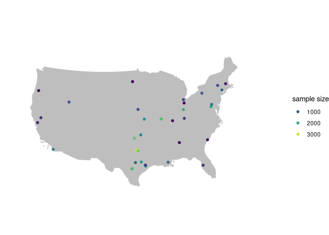

## Clean up taxonomy

We also get classification on various levels for aggregation.

```
## # A tibble: 74 x 8
##    taxa_raw          taxa_clean kingdom   phylum   class   order  family  genus
##    <chr>             <chr>      <chr>     <chr>    <chr>   <chr>  <chr>   <chr>
##  1 Acer              Acer       Viridipl… Strepto… Magnol… Sapin… Sapind… Acer
##  2 Agrocybe-type     Agrocybe   Fungi     Basidio… Agaric… Agari… Stroph… Agroc…
##  3 Alnus             Alnus      Viridipl… Strepto… Magnol… Fagal… Betula… Alnus
##  4 Alternaria        Alternaria Fungi     Ascomyc… Dothid… Pleos… Pleosp… Alter…
##  5 Ambrosia          Ambrosia   Viridipl… Strepto… Magnol… Aster… Astera… Ambro…
##  6 Arecaceae         Arecaceae  Viridipl… Strepto… Magnol… Areca… Arecac… <NA>
##  7 Artemisia         Artemisia  Viridipl… Strepto… Magnol… Aster… Astera… Artem…
##  8 Undifferentiated… Ascomycota Fungi     Ascomyc… <NA>    <NA>   <NA>    <NA>
##  9 Ascospores (Undi… Ascomycota Fungi     Ascomyc… <NA>    <NA>   <NA>    <NA>
## 10 Asteraceae (Excl… Asteraceae Viridipl… Strepto… Magnol… Aster… Astera… <NA>
## # … with 64 more rows
```

## Visualize total spore count

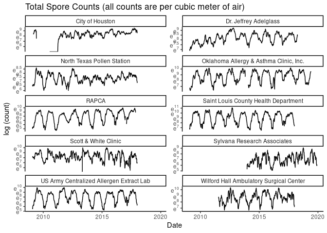

## Visualize community composition

We here show the four most dominant families in comparison to the total spore count.

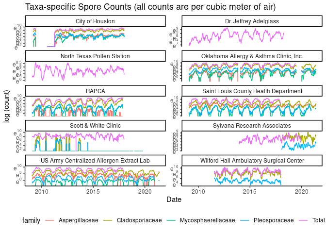

## Visualize phenology

Focusing on the family *Cladosporiaceae*, we visualize the phenology of spores. This figure shows the inter-annual and intra-annual variations in spore count. Note that we are not following calendar years but rather start counting 60 days after Jan 1. This is because the spore count is generally the lowest around day 60. We hope to make sure each cycle has an increasing and then decreasing trend in spore count.

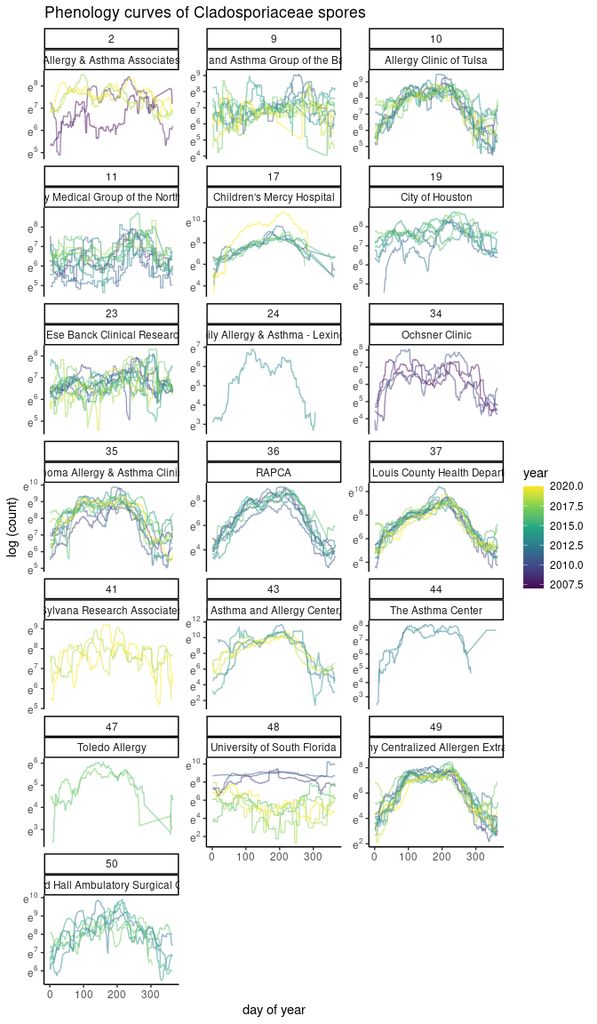

## Naive way to fit model

If we fit each phenology curve with a double logistic phenology model, the phenology can sometimes be described well. However, there are undesirable behaviours, e.g., overfitting, large variations in model parameters that can hardly be interpreted. This is particularly problematic for sites and years without a single peak in spore count or have large observational noise.

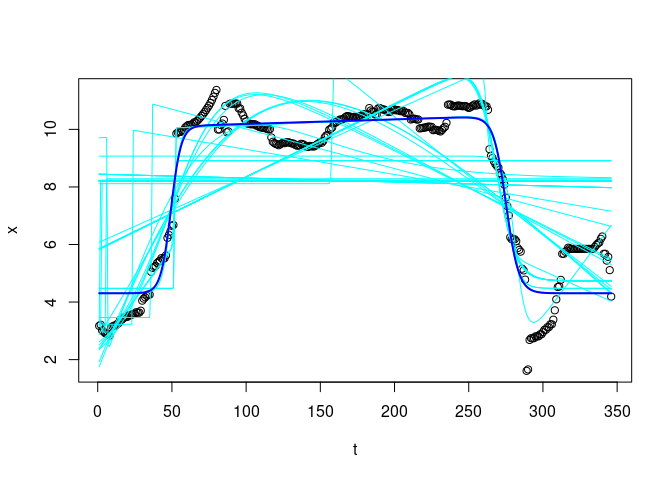

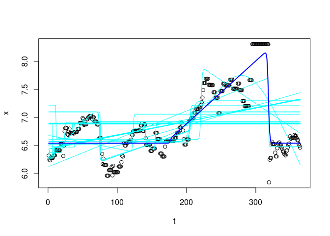

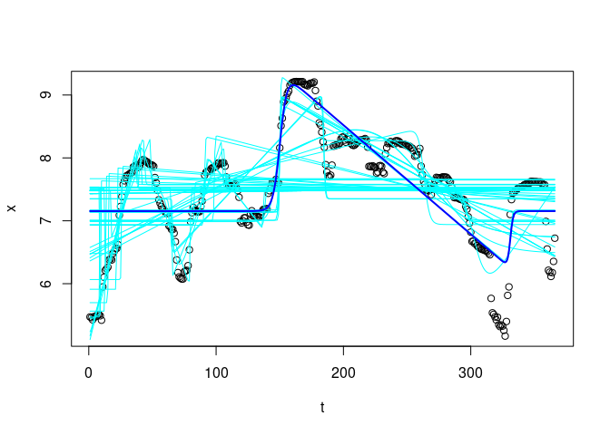

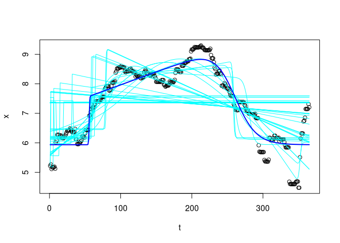

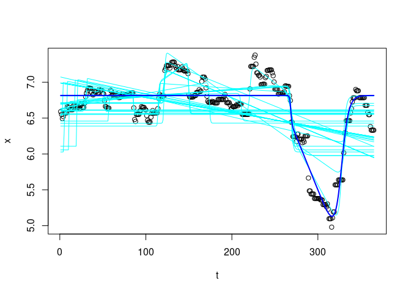

# **Fit hierarchical Bayesian model**

We adopt a hierarchical Bayesian modeling approach to impose reasonable constraints and prior knowledge on model parameters. We are also able to borrow strength from multiple time series to find the general shape of phenology curve.

## Model structure

Due to the very different shapes of phenology curves among sites, we fit a hierarchical Bayesian model for each site independently. We start with a data model, assuming spore count to have a Poisson distribution with the mean $\lambda$, and $log(\lambda)$ to follow a double logistic curve over a year (Elmore et al., 2012).

$$\\
y \sim Poisson(\lambda)\\
log(\lambda)= mn + ((mx-mn) + rsu \times doy) \times(\frac {1}{1+exp((sos-doy)/rsp)}-\frac {1}{1+exp((eos-doy)/rau)})
\\
mn = mn' \times (mn_{max}-mn_{min}) + mn_{min}\\
mx = mx' \times (mx_{max}-mz_{min}) + mx_{min}\\
sos = sos' \times (sos_{max}-sos_{min}) + sos_{min}\\
eos = eos' \times (eos_{max}-eos_{min}) + eos_{min}\\
rsp = rsp' \times (rsp_{max}-rsp_{min}) + rsp_{min}\\
rau = rau' \times (rau_{max}-rau_{min}) + rau_{min}\\
rsu = rsu' \times (rsu_{max}-rsu_{min}) + rsu_{min}\\$$

Each parameter is scaled to $(0,1)$ and then logit-transformed to the real number line. We assume that the transformed parameters each has a mean and year-specific random effects.
$$\\
logit (mn') =\mu_{mn}+\epsilon_{mn,t}\\
logit (mx') =\mu_{mx}+\epsilon_{mx,t}\\
logit (sos') =\mu_{sos}+\epsilon_{sos,t}\\
logit (eos') =\mu_{eos}+\epsilon_{eos,t}\\
logit (rsp') =\mu_{rsp}+\epsilon_{rsp,t}\\
logit (rau') =\mu_{rau}+\epsilon_{rau,t}\\
logit (rsu') =\mu_{rsu}+\epsilon_{rsu,t}\\
\\
\epsilon_{mn,t} \sim N(0, \sigma^{2}_{mn})\\
\epsilon_{mx,t} \sim N(0, \sigma^{2}_{mx})\\
\epsilon_{sos,t} \sim N(0, \sigma^{2}_{sos})\\
\epsilon_{eos,t} \sim N(0, \sigma^{2}_{eos})\\
\epsilon_{rsp,t} \sim N(0, \sigma^{2}_{rsp})\\
\epsilon_{rau,t} \sim N(0, \sigma^{2}_{rau})\\
\epsilon_{rsu,t} \sim N(0, \sigma^{2}_{rsu})\\$$

The priors and hyperparameters are specified below.
$$\\
\mu_{mn}, \mu_{mx} , \mu_{sos} ,\mu_{eos} , \mu_{rsp} , \mu_{rau}, \mu_{rsu} \sim N(0,1)\\
\\
\sigma^{2}_{mn}, \sigma^{2}_{mx}, \sigma^{2}_{sos}, \sigma^{2}_{eos}, \sigma^{2}_{rsp}, \sigma^{2}_{rau},\sigma^{2}_{rsu} \sim Gamma(1, 1e^{-5})$$

$$\\
mn_{min} = -5, mn_{max}=5\\
mx_{min} = 5, mx_{max}=15\\
sos_{min}=0, sos_{max}=183\\
eos_{min}=183, eos_{max}=365\\
rsp_{min}=1, rsp_{max}=61\\
rau_{min}=1, rau_{max}=61\\
rsu_{min}=-0.01, rsu_{max}=0.01\\$$

## Fitting model

We build the model and run MCMC with the *nimble* package.

## Check model fit

This figure shows observed phenology in dashed lines and model-fitted phenology in solid lines. Colors show different sites.

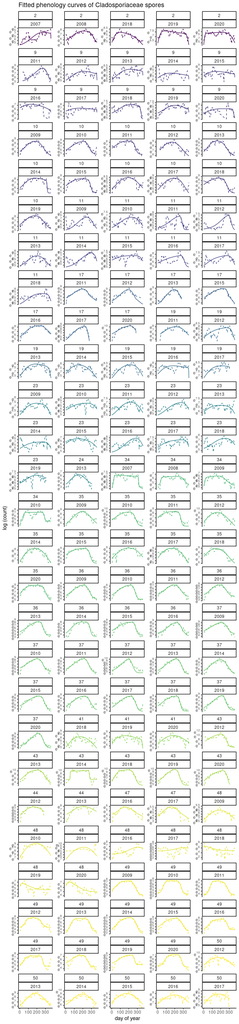

The Pearson correlation between observed and fitted values is 0.9008.

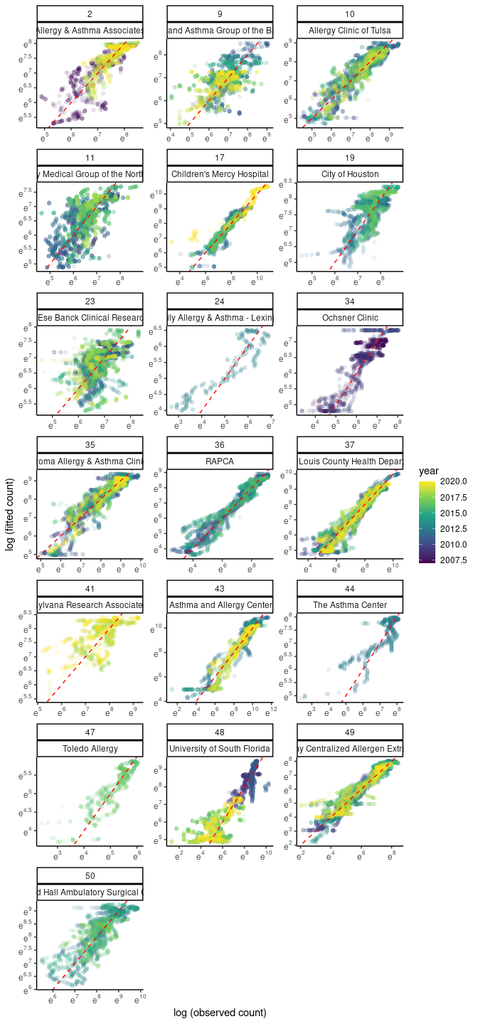

## Inspect model parameters

At first glance, it is not obvious how the model parameters change with sites or year. Colors show different sites.

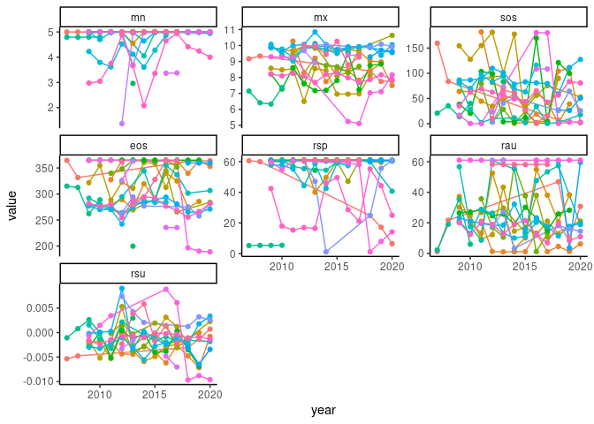

We do see interesting relationships when comparing these phenology model parameters to climatic variables, i.e., mean annual temperature and total annual precipitation. Smoothed line in blue is from generalized linear regression. Colors show different sites. It appears that the phenology parameter-climate relationship is mainly driven by spatial patterns (among sites), rather than temporal patterns (among years).

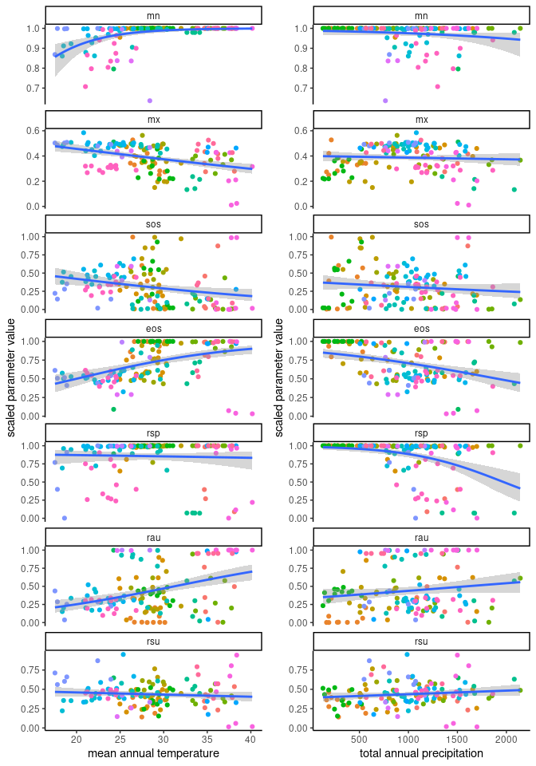

Note: * mn: lower bound of phenology curve * mx: higher bound of phenology curve * sos: timing of spring inflection point * eos: timing of autumn inflection point * rsp: 1 / rate of increase in spring * rau: 1 / rate of decrease in fall * rsu: rate of change during summer

Regression of logit(transformed parameters) against climatic variables support the possible influence of climate on spore phenology.

```
##
## Call:
## lm(formula = logit(t_value) ~ mat + tap, data = df_params %>%
##     filter(param == "mn"))
##
## Residuals:
##    Min     1Q Median     3Q    Max
## -8.033 -1.452  0.370  1.770  4.591
##
## Coefficients:
##               Estimate Std. Error t value Pr(>|t|)
## (Intercept) -2.9154019  1.1539432  -2.526   0.0127 *
## mat          0.4908464  0.0382975  12.817  < 2e-16 ***
## tap         -0.0031826  0.0004494  -7.082 7.62e-11 ***
## ---
## Signif. codes:  0 '***' 0.001 '**' 0.01 '*' 0.05 '.' 0.1 ' ' 1
##
## Residual standard error: 2.334 on 132 degrees of freedom
## Multiple R-squared:  0.6012, Adjusted R-squared:  0.5951
## F-statistic: 99.49 on 2 and 132 DF,  p-value: < 2.2e-16
```

```
##
## Call:
## lm(formula = logit(t_value) ~ mat + tap, data = df_params %>%
##     filter(param == "mx"))
##
## Residuals:
##     Min      1Q  Median      3Q     Max
## -3.5477 -0.3045  0.1197  0.4016  0.9387
##
## Coefficients:
##               Estimate Std. Error t value Pr(>|t|)
## (Intercept)  0.8718471  0.2968203   2.937  0.00391 **
## mat         -0.0452083  0.0098510  -4.589 1.02e-05 ***
## tap         -0.0001048  0.0001156  -0.907  0.36617
## ---
## Signif. codes:  0 '***' 0.001 '**' 0.01 '*' 0.05 '.' 0.1 ' ' 1
##
## Residual standard error: 0.6003 on 132 degrees of freedom
## Multiple R-squared:  0.1477, Adjusted R-squared:  0.1348
## F-statistic: 11.44 on 2 and 132 DF,  p-value: 2.62e-05
```

```
##
## Call:
## lm(formula = logit(t_value) ~ mat + tap, data = df_params %>%
##     filter(param == "sos"))
##
## Residuals:
##     Min      1Q  Median      3Q     Max
## -5.3615 -1.0865  0.1963  1.0108  7.2848
##
## Coefficients:
##               Estimate Std. Error t value Pr(>|t|)
## (Intercept)  2.8558021  1.0732928   2.661 0.008763 **
## mat         -0.1334532  0.0356208  -3.746 0.000267 ***
## tap         -0.0004254  0.0004180  -1.018 0.310688
## ---
## Signif. codes:  0 '***' 0.001 '**' 0.01 '*' 0.05 '.' 0.1 ' ' 1
##
## Residual standard error: 2.171 on 132 degrees of freedom
## Multiple R-squared:  0.1077, Adjusted R-squared:  0.09422
## F-statistic:  7.97 on 2 and 132 DF,  p-value: 0.0005399
```

```
##
## Call:
## lm(formula = logit(t_value) ~ mat + tap, data = df_params %>%
##     filter(param == "eos"))
##
## Residuals:
##     Min      1Q  Median      3Q     Max
## -7.3425 -1.6421 -0.3572  1.2157  6.1255
##
## Coefficients:
##               Estimate Std. Error t value Pr(>|t|)
## (Intercept) -1.8606674  1.3067871  -1.424    0.157
## mat          0.2589647  0.0433701   5.971 2.05e-08 ***
## tap         -0.0033153  0.0005089  -6.514 1.41e-09 ***
## ---
## Signif. codes:  0 '***' 0.001 '**' 0.01 '*' 0.05 '.' 0.1 ' ' 1
##
## Residual standard error: 2.643 on 132 degrees of freedom
## Multiple R-squared:  0.3509, Adjusted R-squared:  0.341
## F-statistic: 35.67 on 2 and 132 DF,  p-value: 4.114e-13
```

```
##
## Call:
## lm(formula = logit(t_value) ~ mat + tap, data = df_params %>%
##     filter(param == "rsp"))
##
## Residuals:
##     Min      1Q  Median      3Q     Max
## -9.4528 -1.5739  0.4323  1.8605  9.1710
##
## Coefficients:
##              Estimate Std. Error t value Pr(>|t|)
## (Intercept)  3.927240   1.556112   2.524   0.0128 *
## mat          0.219925   0.051645   4.258 3.88e-05 ***
## tap         -0.005328   0.000606  -8.791 6.94e-15 ***
## ---
## Signif. codes:  0 '***' 0.001 '**' 0.01 '*' 0.05 '.' 0.1 ' ' 1
##
## Residual standard error: 3.147 on 132 degrees of freedom
## Multiple R-squared:  0.403,  Adjusted R-squared:  0.394
## F-statistic: 44.56 on 2 and 132 DF,  p-value: 1.635e-15
```

```
##
## Call:
## lm(formula = logit(t_value) ~ mat + tap, data = df_params %>%
##     filter(param == "rau"))
##
## Residuals:
##     Min      1Q  Median      3Q     Max
## -9.1457 -1.4290 -0.1677  1.0416  7.9970
##
## Coefficients:
##               Estimate Std. Error t value Pr(>|t|)
## (Intercept) -8.3760770  1.5754524  -5.317 4.38e-07 ***
## mat          0.2414166  0.0522867   4.617 9.11e-06 ***
## tap          0.0017485  0.0006136   2.850  0.00508 **
## ---
## Signif. codes:  0 '***' 0.001 '**' 0.01 '*' 0.05 '.' 0.1 ' ' 1
##
## Residual standard error: 3.187 on 132 degrees of freedom
## Multiple R-squared:  0.1962, Adjusted R-squared:  0.1841
## F-statistic: 16.11 on 2 and 132 DF,  p-value: 5.475e-07
```

```
##
## Call:
## lm(formula = logit(t_value) ~ mat + tap, data = df_params %>%
##     filter(param == "rsu"))
##
## Residuals:
##     Min      1Q  Median      3Q     Max
## -3.8302 -0.3514 -0.0427  0.3670  3.2755
##
## Coefficients:
##               Estimate Std. Error t value Pr(>|t|)
## (Intercept)  0.2721028  0.4373169   0.622   0.5349
## mat         -0.0252589  0.0145138  -1.740   0.0841 .
## tap          0.0001538  0.0001703   0.903   0.3682
## ---
## Signif. codes:  0 '***' 0.001 '**' 0.01 '*' 0.05 '.' 0.1 ' ' 1
##
## Residual standard error: 0.8845 on 132 degrees of freedom
## Multiple R-squared:  0.02639,    Adjusted R-squared:  0.01164
## F-statistic: 1.789 on 2 and 132 DF,  p-value: 0.1712
```

## References

Elmore, A.J., S.M. Guinn, B.J. Minsley and A.D. Richardson (2012): Landscape controls on the timing of spring, autumn, and growing season length in mid-Atlantic forests. - Global Change Biology 18, 656-674.